# Developing Data Products

Monday, June 23, 2014

## The Idea

Now a days is too important think better about best opptions to improve motors performance, even more if we concider energy efficience.

With this in mind, It's interesting find a way to predict **MPG** (*Miles/(US) gallon*) ussing a single linear regressing model between MPG and othes significants terms find in the mtcars dataset from datasets libriry.

Our application allows to cross the result of a prediction with the existing data, and we can dynamically change both the graph as the input data for the prediction and see the effect on-line.

## Exporatory Analysis

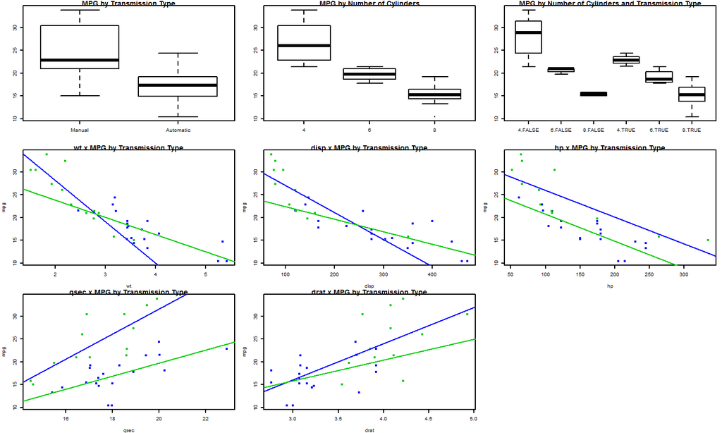

Look this distributions and their linear regressions, we expect a good model with start with automatic and include hp and wt or disp, since the last two appears similars. The drat and qseq maybe change the signal of our others coefficients, and tend to suffer with their outliers.

## The Prediction Model

Our analysis identify a better model **lm(mpg ~ automatic + hp + wt +I(cyl==6) )**, wath is confirmed by anova function evaluation. This model presents a good predictions of MPG, with:

- Minus residuals, where's we can see a **decrease MPG in -2.266 if the transmission is automatic**
- **Attend** our choose of **10% to likelihood ration test** apply at all coefficients.
- The **Residual standard error**, now to **2.4055** on 27 degrees of freedom, our best.

```
##                 Estimate Std. Error t value  Pr(>|t|)
## (Intercept)     36.61435   1.666255  21.974 9.248e-19
## automaticTRUE   -2.26600   1.307888  -1.733 9.458e-02
## hp              -0.04159   0.009326  -4.459 1.301e-04
## wt              -2.67524   0.863678  -3.097 4.518e-03
## I(cyl == 6)TRUE -2.15171   1.055362  -2.039 5.137e-02
```

## Model Results and Residuals Analisis

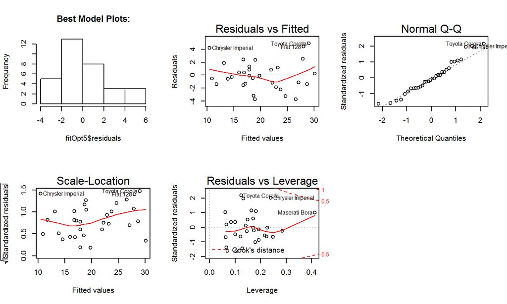

**Note**: The influence of other cylinders (4 and 8) is too similar, with same impact, and don't change much the model performance, so we use model **lm(mpg ~ automatic + hp + wt + cyl)** to apply in our application for you can see it by yourself.